# Predict the correctness of an exercise from accelerometer data

Sonal

August 22, 2017

## Summary

The goal of this project is to use data from accelerometers on the belt, forearm, arm, and dumbell of 6 participants as they perform barbell lifts correctly and incorrectly in 5 different ways and quantify how well they do it.

More information is available from the website here: http://groupware.les.inf.puc-rio.br/har (see the section on the Weight Lifting Exercise Dataset).

## Getting and Cleaning Data

Download and read the training data file and the test data file.

```r
library(caret)

download.file("http://d396qusza40orc.cloudfront.net/predmachlearn/pml-training.csv",
             destfile="pml-training.csv", mode="wb")
download.file("http://d396qusza40orc.cloudfront.net/predmachlearn/pml-testing.csv",
              destfile="pml-testing.csv", mode="wb")
trainData<-read.csv("pml-training.csv", na.strings=c("#DIV/0!","NA"))
testData<-read.csv("pml-testing.csv", na.strings=c("#DIV/0!","NA"))
dim(trainData)
```

```
## [1] 19622   160
```

Check what all features are given in the data and also check for columns with missing values

```r
colnames(trainData)
```

```
##   [1] "X"                        "user_name"
##   [3] "raw_timestamp_part_1"     "raw_timestamp_part_2"
##   [5] "cvtd_timestamp"           "new_window"
##   [7] "num_window"               "roll_belt"
##   [9] "pitch_belt"               "yaw_belt"
##  [11] "total_accel_belt"         "kurtosis_roll_belt"
##  [13] "kurtosis_picth_belt"      "kurtosis_yaw_belt"
##  [15] "skewness_roll_belt"       "skewness_roll_belt.1"
##  [17] "skewness_yaw_belt"        "max_roll_belt"
##  [19] "max_picth_belt"           "max_yaw_belt"
##  [21] "min_roll_belt"            "min_pitch_belt"
##  [23] "min_yaw_belt"             "amplitude_roll_belt"
##  [25] "amplitude_pitch_belt"     "amplitude_yaw_belt"
##  [27] "var_total_accel_belt"     "avg_roll_belt"
##  [29] "stddev_roll_belt"         "var_roll_belt"
```

[output cut: 65 more lines]

```r
missCols <- colSums(is.na(trainData))
```

Remove the first 7 columns which do not help us in data analysis and the columns with missing values

```r
trainData <- trainData[,complete.cases(t(trainData))]
trainData <- trainData[, -c(1:7)]
testData <- testData[,complete.cases(t(testData))]
testData <- testData[, -c(1:7)]
dim(trainData)
```

```
## [1] 19622    53
```

Split the data into training and validation set. (setseed to recreate same partition everytime)

```r
set.seed(20000)
inTrain = createDataPartition(y=trainData$classe, p = 0.7,list=FALSE)
training = trainData[inTrain,]
testing = trainData[-inTrain,]
```

## Our Model

This is a huge data set with lot of features. So, I think Random Forest is a good model for this dataset. With random forest we can get a good classification for all accelerometer readings. ‘trainControl’ is used to specify a resampling method. Here, I am using “repeatedcv”. This method randomly splits the dataset into training and validation data. For each such split, the model is fit to the training data, and predictive accuracy is assessed using the validation data. The results are then averaged over the splits.

```r
ctrl <- trainControl(method="repeatedcv", number=10, repeats=5)
set.seed(20000)

library(doParallel)
cl <- makeCluster(detectCores())
registerDoParallel(cl)

model <- train(classe ~ ., data=training, method="rf", trControl=ctrl)
```

```r
model
```

```
## Random Forest
##
## 13737 samples
##    52 predictor
##     5 classes: 'A', 'B', 'C', 'D', 'E'
##
## No pre-processing
## Resampling: Cross-Validated (10 fold, repeated 5 times)
## Summary of sample sizes: 12364, 12364, 12363, 12363, 12364, 12362, ...
## Resampling results across tuning parameters:
##
##   mtry  Accuracy   Kappa
##    2    0.9927345  0.9908089
##   27    0.9925750  0.9906072
##   52    0.9872895  0.9839202
##
## Accuracy was used to select the optimal model using  the largest value.
## The final value used for the model was mtry = 2.
```

Plot the predicted values of classe variable for the test data set against the given values of classe variable to see the accuracy of our model

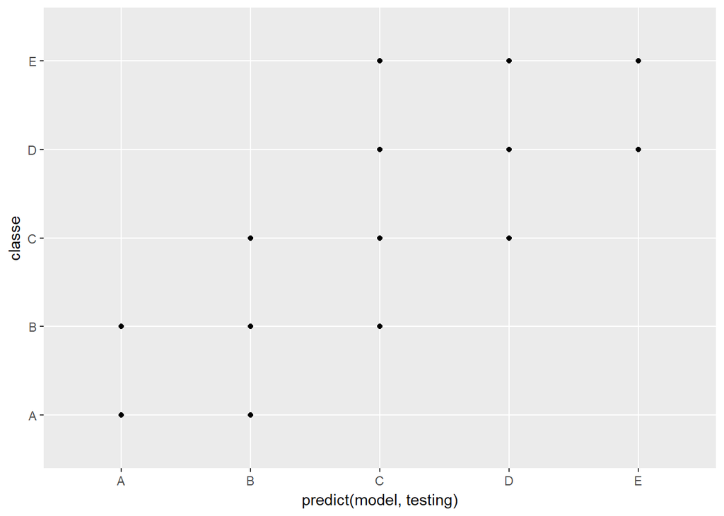

```r
qplot(predict(model,testing),classe,data=testing)
```

```r
modelError <- confusionMatrix(predict(model, newdata=testing), testing$classe)
modelError
```

```
## Confusion Matrix and Statistics
##
##           Reference
## Prediction    A    B    C    D    E
##          A 1671    6    0    0    0
##          B    3 1132    6    0    0
##          C    0    1 1017   27    3
##          D    0    0    3  936    1
##          E    0    0    0    1 1078
##
## Overall Statistics
##
##                Accuracy : 0.9913
##                  95% CI : (0.9886, 0.9935)
##     No Information Rate : 0.2845
##     P-Value [Acc > NIR] : < 2.2e-16
##
##                   Kappa : 0.989
##  Mcnemar's Test P-Value : NA
##
## Statistics by Class:
##
##                      Class: A Class: B Class: C Class: D Class: E
## Sensitivity            0.9982   0.9939   0.9912   0.9710   0.9963
## Specificity            0.9986   0.9981   0.9936   0.9992   0.9998
## Pos Pred Value         0.9964   0.9921   0.9704   0.9957   0.9991
## Neg Pred Value         0.9993   0.9985   0.9981   0.9943   0.9992
## Prevalence             0.2845   0.1935   0.1743   0.1638   0.1839
## Detection Rate         0.2839   0.1924   0.1728   0.1590   0.1832
## Detection Prevalence   0.2850   0.1939   0.1781   0.1597   0.1833
## Balanced Accuracy      0.9984   0.9960   0.9924   0.9851   0.9980
```

Now we know that the model is 99% accurate so we predict the classe values for test data.

```r
predict(model,testData)
```

```
##  [1] B A B A A E D B A A B C B A E E A B B B
## Levels: A B C D E
```